이번 포스트에서는 `tsibble` 클래스의 결측치 처리 방법 중 특별한 방법을 살펴보도록 하겠다.

### tsibble : 그룹화된 결측치 처리

앞선 `tsibble`의 결측치 처리 포스트(https://2stndard.tistory.com/130)에서 `fill_gaps()`의 결과를 보면 특정 값으로 결측치를 대체하거나 함수의 결과값으로 결측치를 처리할 수 있다. 그런데 이 방법은 전체 결측치에 대해 처리되기 때문에 특정값을 설정하면 처음부터 끝까지 결측치를 동일한 값으로 처리하고 함수의 경우도 전체 데이터 대상의 함수 적용 결과값을 사용하기 때문에 전체적으로 같은 값이 결측치에 반영된다. 앞 포스트의 그래프를 보면 `median()` 함수가 적용되는 구간이 전체 데이터를 대상으로 하기 때문에 전체 데이터에 대한 중간값이 결측치에 대체된다.

하지만 결측치를 그룹별로 각각 다른 값으로 대체하거나 그룹별로 적용되는 함수의 결과로 결측치를 대체해야 좀 더 효율적인 결측치 처리가 될 것이다. 예를 들어 앞 포스트의 `median()`을 연도별 중간값을 사용하고자 한다면 어떻게 할 것인가? 조금은 복잡하지만 다음과 같이 처리할 수 있다.

```r
tsAirgap.tsibble |>
  index_by(Year_Month = ~ lubridate::year(.)) |>
  ungroup() |>
  as_tsibble(index = index, key = Year_Month) |>
  group_by_key(Year_Month) |>
  fill_gaps(value = median(value), .full = FALSE) |>
  as_data_frame() |>
  select(-Year_Month) |>
  as_tsibble(index = index)
```

```
## # A tsibble: 143 x 2 [1M]
##      index value
##      <mth> <dbl>
##  1  1949 1   112
##  2  1949 2   118
##  3  1949 3   132
##  4  1949 4   129
##  5  1949 5   124
##  6  1949 6   135
##  7  1949 7   148
##  8  1949 8   148
##  9  1949 9   124
## 10 1949 10   119
## # ... with 133 more rows
```

처리된 결측치를 시각화하면 다음과 같다.

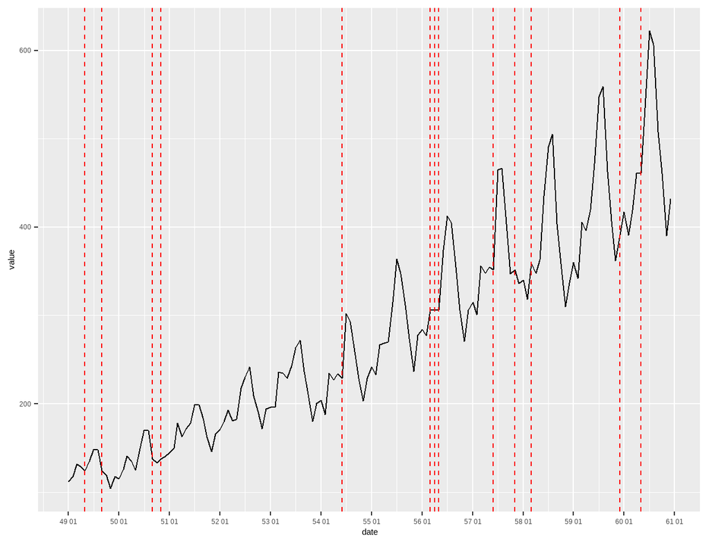

```r
tsAirgap.tsibble |>
  fill_gaps() |>
  filter(is.na(value)) |>
  mutate(date = as.Date(paste(index, '01'), '%Y %m %d')) -> missing_yearmon

tsAirgap.tsibble |>
  index_by(Year_Month = ~ lubridate::year(.)) |>
  ungroup() |>
  as_tsibble(index = index, key = Year_Month) |>
  group_by_key(Year_Month) |>
  fill_gaps(value = median(value), .full = FALSE) |>
  as_data_frame() |>
  mutate(date = as.Date(paste(index, '01'), '%Y %m %d')) |>
  ggplot(aes(x = date, y = value)) +
  geom_line(aes(group = 1)) +
  geom_vline(data = missing_yearmon, aes(xintercept = date), color = 'red', linetype = 'dashed') +
  scale_x_date(date_breaks = '1 year', date_labels = '%y %m')
```

결측치를 연도별 평균값으로 처리한다면 다음과 같이 처리한다.

```r
tsAirgap.tsibble |>
  index_by(Year_Month = ~ lubridate::year(.)) |>
  ungroup() |>
  as_tsibble(index = index, key = Year_Month) |>
  group_by_key(Year_Month) |>
  fill_gaps(value = mean(value), .full = FALSE) |>
  as_data_frame() |>
  select(-Year_Month) |>
  as_tsibble(index = index)
```

```
## # A tsibble: 143 x 2 [1M]
##      index value
##      <mth> <dbl>
##  1  1949 1  112
##  2  1949 2  118
##  3  1949 3  132
##  4  1949 4  129
##  5  1949 5  126.
##  6  1949 6  135
##  7  1949 7  148
##  8  1949 8  148
##  9  1949 9  126.
## 10 1949 10  119
## # ... with 133 more rows
```

### fable : tsibble 데이터의 선형 보간, 계절성 보간

`fable` 패키지는 시계열 전용 패키지인 `forecast` 패키지를 tidy하게 재구축한 패키지이다. 시계열에 관련하여 Tidyverse 생태계를 준용한 모델링과 분석을 위한 다양한 기능을 제공한다.

```r
if (!require(fable)) {
  install.packages('fable')
  library(fable)
}
```

#### 선형 회귀 모델을 사용한 보간

앞서 `tsibble` 패키지의 `fill_gaps()`를 사용하면 결측치에 특정 값으로 메우거나 함수를 사용하여 계산된 값을 메울 수 있다. 하지만 선형 회귀를 통한 보간법은 제공하지 않는데 `fable` 패키지를 사용하면 `tsibble`의 선형 회귀를 통한 보간법을 사용할 수 있다. 선형 회귀 보간법외에도 ETS 등의 시계열 모델링을 사용한 보간도 가능하다.

선형 회귀 모델을 사용한 결측치 처리는 다음과 같다.

```r
fill_gaps(tsAirgap.tsibble, .full = TRUE) %>%
  model(lm = TSLM(value ~ trend())) %>%
  interpolate(fill_gaps(tsAirgap.tsibble, .full = TRUE))
```

```
## # A tsibble: 144 x 2 [1M]
##      index value
##      <mth> <dbl>
##  1  1949 1 112
##  2  1949 2 118
##  3  1949 3 132
##  4  1949 4 129
##  5  1949 5  99.9
##  6  1949 6 135
##  7  1949 7 148
##  8  1949 8 148
##  9  1949 9 111.
## 10 1949 10 119
## # ... with 134 more rows
```

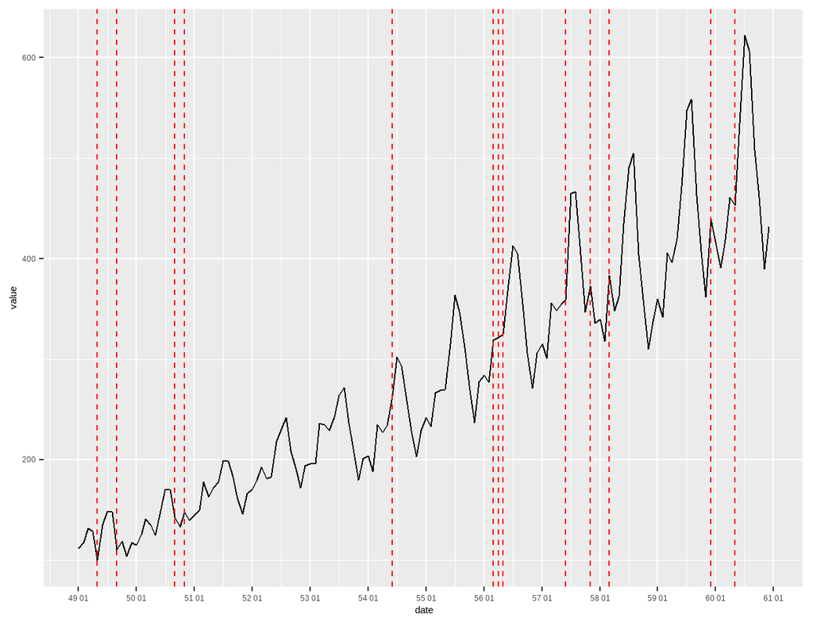

```r
fill_gaps(tsAirgap.tsibble, .full = TRUE) %>%
  model(lm = TSLM(value ~ trend())) %>%
  interpolate(fill_gaps(tsAirgap.tsibble, .full = TRUE)) |>
  as_data_frame() |>
  mutate(date = as.Date(paste(index, '01'), '%Y %m %d')) |>
  ggplot(aes(x = date, y = value)) +
  geom_line(aes(group = 1)) +
  geom_vline(data = missing_yearmon, aes(xintercept = date), color = 'red', linetype = 'dashed') +
  scale_x_date(date_breaks = '1 year', date_labels = '%y %m')
```

#### 선형 회귀와 계절성 모델을 사용한 보간

이 선형 회귀 모델에는 계절성이 누락되어 있다. 계절성을 포함한 결측치의 처리는 다음과 같다.

```r
fill_gaps(tsAirgap.tsibble, .full = TRUE) %>%
  model(lm = TSLM(value ~ trend() + season())) %>%
  interpolate(fill_gaps(tsAirgap.tsibble, .full = TRUE))
```

```
## # A tsibble: 144 x 2 [1M]
##      index value
##      <mth> <dbl>
##  1  1949 1 112
##  2  1949 2 118
##  3  1949 3 132
##  4  1949 4 129
##  5  1949 5  90.3
##  6  1949 6 135
##  7  1949 7 148
##  8  1949 8 148
##  9  1949 9 125.
## 10 1949 10 119
## # ... with 134 more rows
```

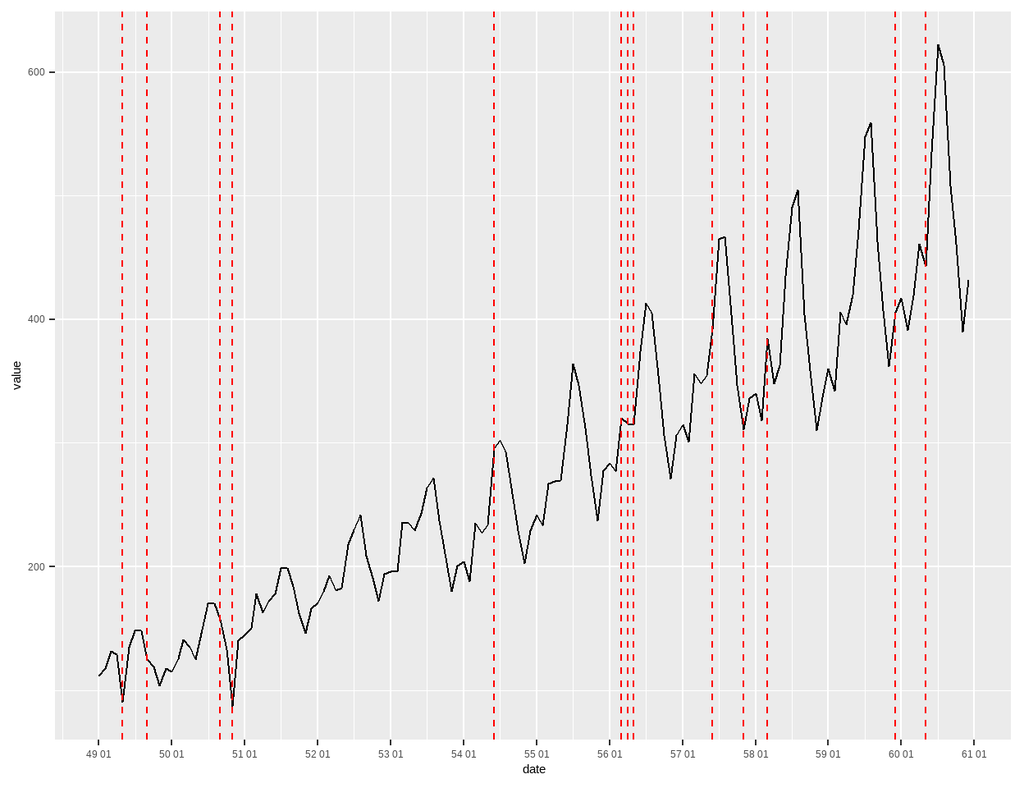

```r
fill_gaps(tsAirgap.tsibble, .full = TRUE) %>%
  model(lm = TSLM(value ~ trend() + season())) %>%
  interpolate(fill_gaps(tsAirgap.tsibble, .full = TRUE)) |>
  as_data_frame() |>
  mutate(date = as.Date(paste(index, '01'), '%Y %m %d')) |>
  ggplot(aes(x = date, y = value)) +
  geom_line(aes(group = 1)) +
  geom_vline(data = missing_yearmon, aes(xintercept = date), color = 'red', linetype = 'dashed') +
  scale_x_date(date_breaks = '1 year', date_labels = '%y %m')
```